# Outliers_multivarie

```r
library(data.table)
library(caret)
```

```r
library(ggplot2)
library(dplyr)
library(rmarkdown)
don <- read.csv('2_Data/2_Retraitees/SiWIM_data_after_input_clusters.csv',header=T)
dim(don)
```

```
## [1] 100571     41
```

```r
names(don)
```

```
##  [1] "X.1"                 "X"                   "Timestamp"
##  [4] "Site_ID"             "Warning_flags"       "Subclass_ID"
##  [7] "Axle_groups"         "A1"                  "A2"
## [10] "A3"                  "A4"                  "A5"
## [13] "A6"                  "A7"                  "Date"
## [16] "Horaire"             "Annee"               "Mois_num"
## [19] "Mois_annee"          "Jour_num"            "Jour_semaine"
## [22] "Heure"               "M1"                  "M2"
## [25] "M3"                  "M4"                  "M5"
## [28] "M6"                  "M7"                  "M8"
## [31] "Lane"                "N"                   "Nb_axles"
## [34] "Anomalie"            "total_axle_dist"     "T"
## [37] "Reduced_chi_squared" "Time_num"            "Vitesse"
## [40] "MGV"                 "clusters_kmeans"
```

```r
don[is.na(don)] <- 0
don <- don[,c("Warning_flags","A1","A2","A3","A4","A5","A6","A7",
                      "M1","M2","M3","M4","M5","M6","M7","M8","N",
                      "Reduced_chi_squared", "Vitesse", "MGV", "clusters_kmeans")]
```

# Approche multivariÃ©e

Pour l’approche multivariée: + On cherche un modèle représentant les données, + puis avec ce modèle on définit les outliers comme les individus ayant une distance de Cook supérieure Ã 4 fois la distance de Cook moyenne.

La valeur 4 n’est pas une valeur fixe ou dÃ©finitive.

De plus, d’autres approches peuvent être mises en place, par exemple avec les résidues, les hat values et les valeurs de r-student.

## Recherche du modÃ¨le avec caret

```r
ptm <- proc.time()

train <- don[1:1000,c("A1","A2","A3","A4","A5","A6","A7",
                 "M1","M2","M3","M4","M5","M6","M7","M8","N",
                 "Vitesse", "MGV", "Reduced_chi_squared")]

str(train)
```

```
## 'data.frame':    1000 obs. of  19 variables:
##  $ A1                 : num  3.9 3.54 2.37 3.8 3.72 ...
##  $ A2                 : num  5.68 0 0 5.92 5.68 ...
##  $ A3                 : num  1.33 0 0 1.28 1.33 ...
##  $ A4                 : num  1.33 0 0 1.37 1.33 ...
##  $ A5                 : num  0 0 0 0 0 ...
##  $ A6                 : num  0 0 0 0 0 0 0 0 0 0 ...
##  $ A7                 : num  0 0 0 0 0 0 0 0 0 0 ...
##  $ M1                 : num  4.681 1.955 0.888 5.094 5.063 ...
##  $ M2                 : num  8.728 2.871 0.771 8.109 9.024 ...
##  $ M3                 : num  4.24 0 0 1.75 4.66 ...
##  $ M4                 : num  5.92 0 0 3.56 6.88 ...
##  $ M5                 : num  5.83 0 0 3.37 6.49 ...
##  $ M6                 : num  0 0 0 0 0 ...
##  $ M7                 : num  0 0 0 0 0 0 0 0 0 0 ...
##  $ M8                 : num  0 0 0 0 0 0 0 0 0 0 ...
##  $ N                  : num  5 2 2 5 5 5 5 6 5 5 ...
##  $ Vitesse            : num  76.4 74.1 74.1 81.5 68 ...
##  $ MGV                : num  29.39 4.83 1.66 21.89 32.12 ...
##  $ Reduced_chi_squared: num  391.59 4.25 13.85 401.02 521.62 ...
```

```r
sum(is.na(train))
```

```
## [1] 0
```

```r
preProcValues <- caret::preProcess(train, method = c("knnImpute","center","scale"))
sum(is.na(train))
```

```
## [1] 0
```

```r
library('RANN')
train_processed <- predict(preProcValues, train)
sum(is.na(train_processed))
```

```
## [1] 0
```

```r
str(train_processed)
```

```
## 'data.frame':    1000 obs. of  19 variables:
##  $ A1                 : num  -0.117 -0.49 -1.701 -0.216 -0.297 ...
##  $ A2                 : num  0.454 -1.801 -1.801 0.55 0.453 ...
##  $ A3                 : num  -0.0431 -1.0018 -1.0018 -0.0754 -0.0426 ...
##  $ A4                 : num  0.386 -0.896 -0.896 0.429 0.387 ...
##  $ A5                 : num  -0.18 -0.18 -0.18 -0.18 -0.18 ...
##  $ A6                 : num  -0.115 -0.115 -0.115 -0.115 -0.115 ...
##  $ A7                 : num  -0.0941 -0.0941 -0.0941 -0.0941 -0.0941 ...
##  $ M1                 : num  0.0765 -1.2348 -1.7481 0.2752 0.26 ...
##  $ M2                 : num  0.538 -0.987 -1.533 0.377 0.615 ...
##  $ M3                 : num  0.586 -1.098 -1.098 -0.404 0.75 ...
##  $ M4                 : num  0.8448 -1.0816 -1.0816 0.0782 1.1601 ...
##  $ M5                 : num  1.107 -0.839 -0.839 0.288 1.328 ...
##  $ M6                 : num  -0.133 -0.133 -0.133 -0.133 -0.133 ...
##  $ M7                 : num  -0.0543 -0.0543 -0.0543 -0.0543 -0.0543 ...
##  $ M8                 : num  0 0 0 0 0 0 0 0 0 0 ...
##  $ N                  : num  0.58 -1.93 -1.93 0.58 0.58 ...
##  $ Vitesse            : num  0.527 0.325 0.325 0.972 -0.216 ...
##  $ MGV                : num  0.70292 -1.61637 -1.91535 -0.00578 0.9598 ...
##  $ Reduced_chi_squared: num  -0.16211 -0.6591 -0.64679 -0.15 0.00473 ...
```

L’échantillon de données est coupé en deux, pour la pouplation d’apprentissage (75%) et celle de test (25%). Cela est fait facilement avec la fonction createDataPartition du package caret.

```r
index <- createDataPartition(train_processed$MGV, p=0.75, list=FALSE)
trainSet <- train_processed[ index,]
testSet <- train_processed[-index,]

str(trainSet)
```

```
## 'data.frame':    752 obs. of  19 variables:
##  $ A1                 : num  -0.117 -0.49 -1.701 -0.216 -0.297 ...
##  $ A2                 : num  0.454 -1.801 -1.801 0.55 0.453 ...
##  $ A3                 : num  -0.0431 -1.0018 -1.0018 -0.0754 -0.0426 ...
##  $ A4                 : num  0.386 -0.896 -0.896 0.429 0.387 ...
##  $ A5                 : num  -0.18 -0.18 -0.18 -0.18 -0.18 ...
##  $ A6                 : num  -0.115 -0.115 -0.115 -0.115 -0.115 ...
##  $ A7                 : num  -0.0941 -0.0941 -0.0941 -0.0941 -0.0941 ...
##  $ M1                 : num  0.0765 -1.2348 -1.7481 0.2752 0.26 ...
##  $ M2                 : num  0.538 -0.987 -1.533 0.377 0.615 ...
##  $ M3                 : num  0.586 -1.098 -1.098 -0.404 0.75 ...
##  $ M4                 : num  0.8448 -1.0816 -1.0816 0.0782 1.1601 ...
##  $ M5                 : num  1.107 -0.839 -0.839 0.288 1.328 ...
##  $ M6                 : num  -0.133 -0.133 -0.133 -0.133 -0.133 ...
##  $ M7                 : num  -0.0543 -0.0543 -0.0543 -0.0543 -0.0543 ...
##  $ M8                 : num  0 0 0 0 0 0 0 0 0 0 ...
##  $ N                  : num  0.58 -1.93 -1.93 0.58 0.58 ...
##  $ Vitesse            : num  0.527 0.325 0.325 0.972 -0.216 ...
##  $ MGV                : num  0.70292 -1.61637 -1.91535 -0.00578 0.9598 ...
##  $ Reduced_chi_squared: num  -0.16211 -0.6591 -0.64679 -0.15 0.00473 ...
```

On utilise la fonction rfe pour contrôler les features (ici validation croisée, avec 3 répétitions).

De plus, le calage de modèle est aussi contrôlée par validation croisée, avec 5 répétitions.

```r
control <- rfeControl(functions = rfFuncs,
                      method = "repeatedcv",
                      repeats = 3,
                      verbose = FALSE)
outcomeName<-'MGV'
predictors<-names(trainSet)[!names(trainSet) %in% outcomeName]
MGV_Pred_Profile <- rfe(trainSet[,predictors], trainSet[,outcomeName],
                         rfeControl = control)
MGV_Pred_Profile
```

```
##
## Recursive feature selection
##
## Outer resampling method: Cross-Validated (10 fold, repeated 3 times)
##
## Resampling performance over subset size:
##
##  Variables   RMSE Rsquared    MAE  RMSESD RsquaredSD   MAESD Selected
##          4 0.2903   0.9189 0.1713 0.06075    0.03253 0.02646
##          8 0.2006   0.9631 0.1192 0.05595    0.01951 0.02279
##         16 0.1824   0.9691 0.1071 0.04974    0.01551 0.01920
##         18 0.1808   0.9696 0.1056 0.04961    0.01536 0.01884        *
##
## The top 5 variables (out of 18):
##    M2, M3, M5, M1, M4
```

```r
names(getModelInfo())
```

```
##   [1] "ada"                 "AdaBag"              "AdaBoost.M1"
##   [4] "adaboost"            "amdai"               "ANFIS"
##   [7] "avNNet"              "awnb"                "awtan"
##  [10] "bag"                 "bagEarth"            "bagEarthGCV"
##  [13] "bagFDA"              "bagFDAGCV"           "bam"
##  [16] "bartMachine"         "bayesglm"            "binda"
##  [19] "blackboost"          "blasso"              "blassoAveraged"
##  [22] "bridge"              "brnn"                "BstLm"
##  [25] "bstSm"               "bstTree"             "C5.0"
##  [28] "C5.0Cost"            "C5.0Rules"           "C5.0Tree"
##  [31] "cforest"             "chaid"               "CSimca"
##  [34] "ctree"               "ctree2"              "cubist"
##  [37] "dda"                 "deepboost"           "DENFIS"
##  [40] "dnn"                 "dwdLinear"           "dwdPoly"
##  [43] "dwdRadial"           "earth"               "elm"
```

[output cut: 65 more lines]

```r
fitControl <- trainControl(
  method = "repeatedcv",
  number = 5,
  repeats = 5)
```

```r
model_glm<-train(trainSet[,predictors],trainSet[,outcomeName],method='gbm',trControl=fitControl,tuneLength=10)
print(model_glm)
```

```
## Stochastic Gradient Boosting
##
## 752 samples
##  18 predictor
##
## No pre-processing
## Resampling: Cross-Validated (5 fold, repeated 5 times)
## Summary of sample sizes: 602, 601, 601, 602, 602, 601, ...
## Resampling results across tuning parameters:
##
##   interaction.depth  n.trees  RMSE       Rsquared   MAE
##    1                  50      0.3418573  0.9032008  0.23647112
##    1                 100      0.2568747  0.9376227  0.17299135
##    1                 150      0.2317445  0.9472645  0.15314119
##    1                 200      0.2213432  0.9515420  0.14427385
```

[output cut: 103 more lines]

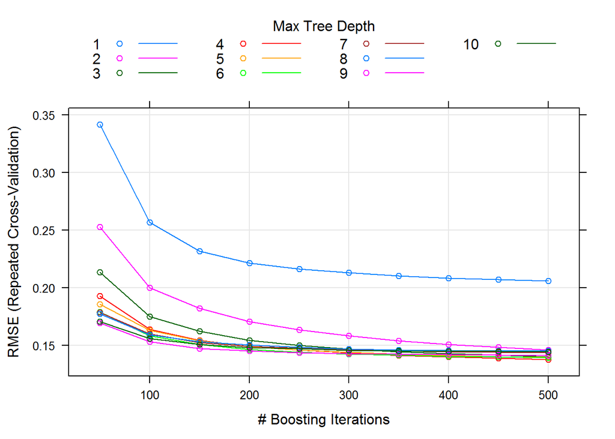

```r
plot(model_glm)
```

```r
model_rqlasso<-train(trainSet[,predictors],trainSet[,outcomeName],method='rqlasso',
                     ,trControl=fitControl,tuneLength=10)
print(model_rqlasso)
```

```
## Quantile Regression with LASSO penalty
##
## 752 samples
##  18 predictor
##
## No pre-processing
## Resampling: Cross-Validated (5 fold, repeated 5 times)
## Summary of sample sizes: 604, 603, 600, 600, 601, 600, ...
## Resampling results across tuning parameters:
##
##   lambda        RMSE       Rsquared   MAE
##   0.0001000000  0.6094920  0.7149845  0.1622299
##   0.0002154435  0.6008460  0.7220992  0.1609404
##   0.0004641589  0.6005447  0.7223459  0.1608872
##   0.0010000000  0.6001589  0.7225648  0.1609210
##   0.0021544347  0.5948068  0.7259725  0.1600856
##   0.0046415888  0.5888503  0.7319650  0.1602314
##   0.0100000000  0.5836393  0.7387369  0.1607974
##   0.0215443469  0.5924747  0.7339552  0.1639273
##   0.0464158883  0.6103884  0.7219368  0.1690728
##   0.1000000000  0.5912609  0.7254364  0.1995173
##
## RMSE was used to select the optimal model using the smallest value.
## The final value used for the model was lambda = 0.01.
```

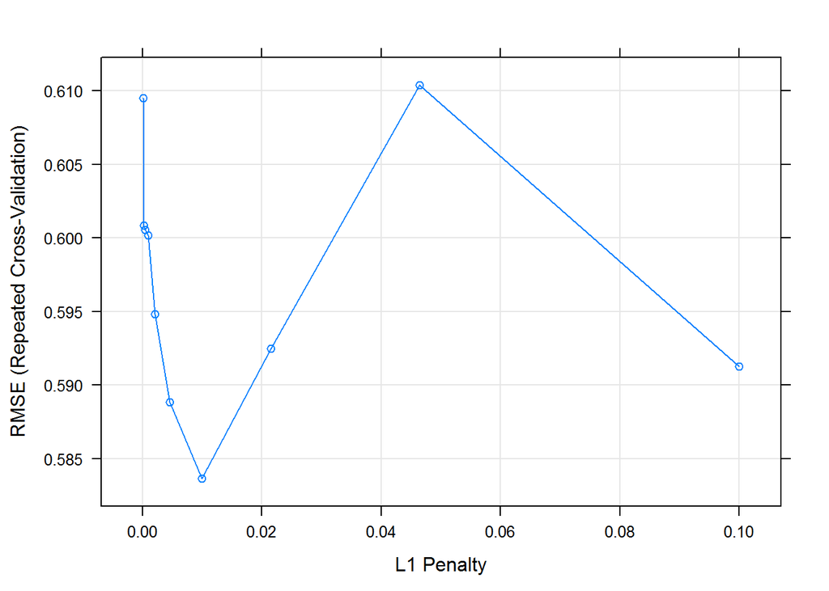

```r
plot(model_rqlasso)
```

## Forêts aléatoires

```r
model_rf<-train(trainSet[,predictors],trainSet[,outcomeName],method='rf',
                ,trControl=fitControl,tuneLength=10) # random Forest
print(model_rf)
```

```
## Random Forest
##
## 752 samples
##  18 predictor
##
## No pre-processing
## Resampling: Cross-Validated (5 fold, repeated 5 times)
## Summary of sample sizes: 602, 602, 601, 602, 601, 601, ...
## Resampling results across tuning parameters:
##
##   mtry  RMSE       Rsquared   MAE
##    2    0.2707808  0.9430228  0.1851973
##    3    0.2255756  0.9561992  0.1430949
##    5    0.1969012  0.9643747  0.1152028
##    7    0.1883569  0.9665249  0.1065444
##    9    0.1871113  0.9664793  0.1044754
##   10    0.1871127  0.9662573  0.1043246
##   12    0.1882233  0.9656025  0.1053516
##   14    0.1904307  0.9645918  0.1070315
##   16    0.1945599  0.9628302  0.1097032
##   18    0.1984874  0.9611517  0.1124600
##
## RMSE was used to select the optimal model using the smallest value.
## The final value used for the model was mtry = 9.
```

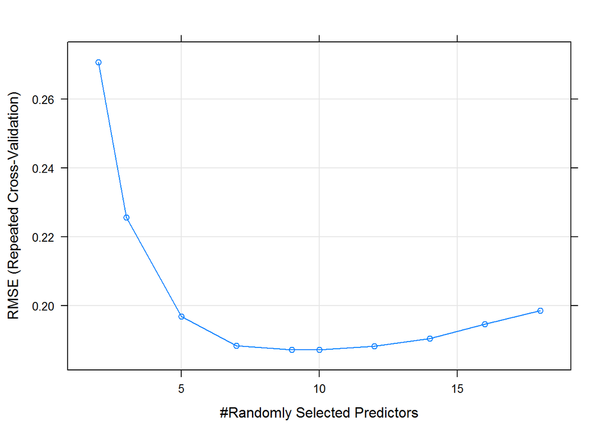

```r
plot(model_rf)
```

## Gradient boosting

```r
model_gbm<-train(trainSet[,predictors],trainSet[,outcomeName],method='gbm',
                 ,trControl=fitControl,tuneLength=10) #Stochastic Gradient Boosting
print(model_gbm)
```

```
## Stochastic Gradient Boosting
##
## 752 samples
##  18 predictor
##
## No pre-processing
## Resampling: Cross-Validated (5 fold, repeated 5 times)
## Summary of sample sizes: 601, 601, 602, 602, 602, 601, ...
## Resampling results across tuning parameters:
##
##   interaction.depth  n.trees  RMSE       Rsquared   MAE
##    1                  50      0.3425576  0.9024355  0.23747998
##    1                 100      0.2607937  0.9358433  0.17586147
##    1                 150      0.2347325  0.9463387  0.15606717
##    1                 200      0.2249114  0.9505254  0.14698181
```

[output cut: 103 more lines]

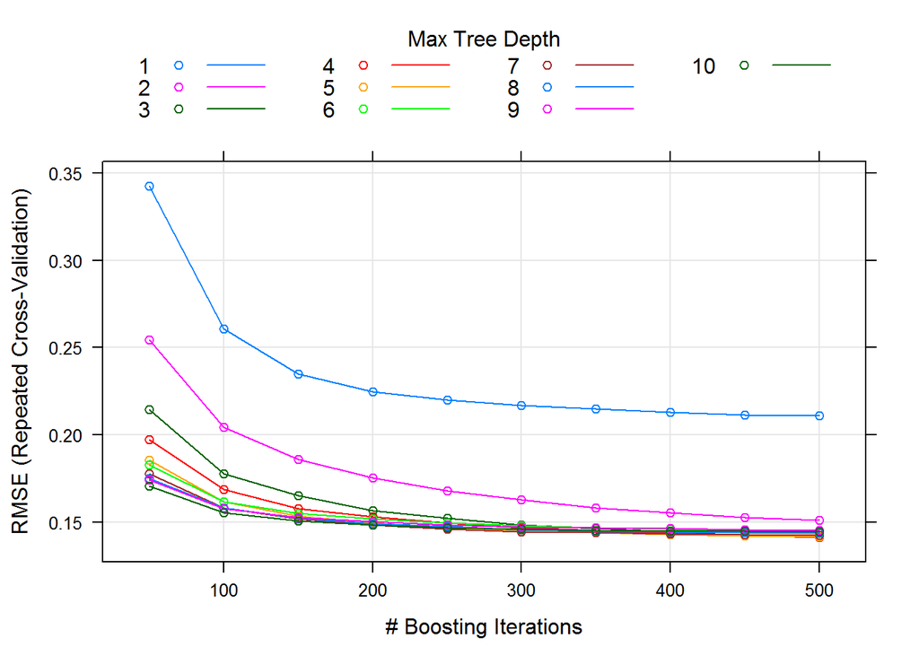

```r
plot(model_gbm)
```

## Comparaison des différents modèles

```r
results <- resamples(list(mod.glm=model_glm,
                          mod.rqlasso=model_rqlasso,
                          mod.rf=model_rf,
                          mod.rf=model_rf, mod.gbm=model_gbm))
results$values
```

| Resample | mod.rf~MAE | mod.rf~RMSE | mod.rf~Rsquared | mod.glm~MAE | mod.glm~RMSE | mod.glm~Rsquared | mod.rqlasso~MAE | mod.rqlasso~RMSE | mod.rqlasso~Rsquared | mod.gbm~MAE | mod.gbm~RMSE | mod.gbm~Rsquared |
| --- | --- | --- | --- | --- | --- | --- | --- | --- | --- | --- | --- | --- |
| Fold1.Rep1 | 0.10672500 | 0.1957815 | 0.9709297 | 0.09133634 | 0.1371046 | 0.9810278 | 0.15883519 | 0.5538015 | 0.7681495 | 0.08689303 | 0.1256515 | 0.9838290 |
| Fold1.Rep2 | 0.13008676 | 0.2519261 | 0.9476954 | 0.09241930 | 0.1632991 | 0.9780248 | 0.13195086 | 0.5293057 | 0.7704336 | 0.09548680 | 0.1683336 | 0.9748519 |
| Fold1.Rep3 | 0.09990260 | 0.1617917 | 0.9710498 | 0.07499553 | 0.1010588 | 0.9896390 | 0.17495035 | 0.6109638 | 0.7235564 | 0.08527768 | 0.1579892 | 0.9771378 |
| Fold1.Rep4 | 0.10324481 | 0.1996971 | 0.9644454 | 0.09847701 | 0.1484907 | 0.9772201 | 0.15897046 | 0.5862177 | 0.7389022 | 0.09390868 | 0.1574147 | 0.9776514 |
| Fold1.Rep5 | 0.10582668 | 0.1844861 | 0.9688161 | 0.08964094 | 0.1562930 | 0.9746326 | 0.08773442 | 0.4261973 | 0.8570457 | 0.09535871 | 0.1541612 | 0.9768906 |
| Fold2.Rep1 | 0.10768415 | 0.2006658 | 0.9584823 | 0.09029255 | 0.1516134 | 0.9799760 | 0.17161334 | 0.6347344 | 0.7269320 | 0.09065055 | 0.1408908 | 0.9797311 |
| Fold2.Rep2 | 0.08875397 | 0.1430772 | 0.9800318 | 0.08417624 | 0.1348361 | 0.9824788 | 0.14385110 | 0.5636211 | 0.7400773 | 0.08227620 | 0.1441295 | 0.9780185 |
| Fold2.Rep3 | 0.09755881 | 0.1409130 | 0.9838256 | 0.08722271 | 0.1537481 | 0.9782964 | 0.22225121 | 0.7126208 | 0.6057798 | 0.08783969 | 0.1404596 | 0.9809200 |
| Fold2.Rep4 | 0.11283601 | 0.2183600 | 0.9581854 | 0.10140150 | 0.1718652 | 0.9721319 | 0.16239130 | 0.6068893 | 0.7326934 | 0.07049388 | 0.1027541 | 0.9883585 |
| Fold2.Rep5 | 0.09315931 | 0.1495093 | 0.9773950 | 0.07870013 | 0.1114858 | 0.9877057 | 0.16352633 | 0.6013388 | 0.7205363 | 0.08554297 | 0.1510408 | 0.9801676 |

[output cut: 15 more lines]

```r
summary(results)
```

```
##
## Call:
## summary.resamples(object = results)
##
## Models: mod.glm, mod.rqlasso, mod.rf, mod.rf, mod.gbm
## Number of resamples: 25
##
## MAE
##                   Min.    1st Qu.     Median       Mean    3rd Qu.
## mod.rf      0.07600178 0.09990260 0.10324481 0.10447542 0.11031239
## mod.glm     0.06642366 0.07870013 0.08793431 0.08576057 0.09133634
## mod.rqlasso 0.08150507 0.13361138 0.16239130 0.16079741 0.18536642
## mod.gbm     0.07049388 0.07965207 0.08746277 0.08667663 0.09365368
##                  Max. NA's
## mod.rf      0.1300868    0
## mod.glm     0.1014015    0
## mod.rqlasso 0.2460857    0
## mod.gbm     0.1008641    0
##
## RMSE
##                  Min.   1st Qu.    Median      Mean   3rd Qu.      Max.
## mod.rf      0.1104302 0.1617917 0.1922473 0.1871113 0.2045081 0.2519261
## mod.glm     0.1002329 0.1237334 0.1382099 0.1376240 0.1562930 0.1718652
## mod.rqlasso 0.3999076 0.5299980 0.5989365 0.5836393 0.6347344 0.7518886
## mod.gbm     0.1027541 0.1256515 0.1435956 0.1413651 0.1574147 0.1754434
##             NA's
## mod.rf         0
## mod.glm        0
## mod.rqlasso    0
## mod.gbm        0
##
## Rsquared
##                  Min.   1st Qu.    Median      Mean   3rd Qu.      Max.
## mod.rf      0.9476493 0.9585786 0.9659103 0.9664793 0.9737447 0.9897875
## mod.glm     0.9721319 0.9772445 0.9810278 0.9813893 0.9858367 0.9904774
## mod.rqlasso 0.6009168 0.6937525 0.7326934 0.7387369 0.7704336 0.8572702
## mod.gbm     0.9731130 0.9771378 0.9801676 0.9805090 0.9838290 0.9883585
##             NA's
## mod.rf         0
## mod.glm        0
## mod.rqlasso    0
## mod.gbm        0
```

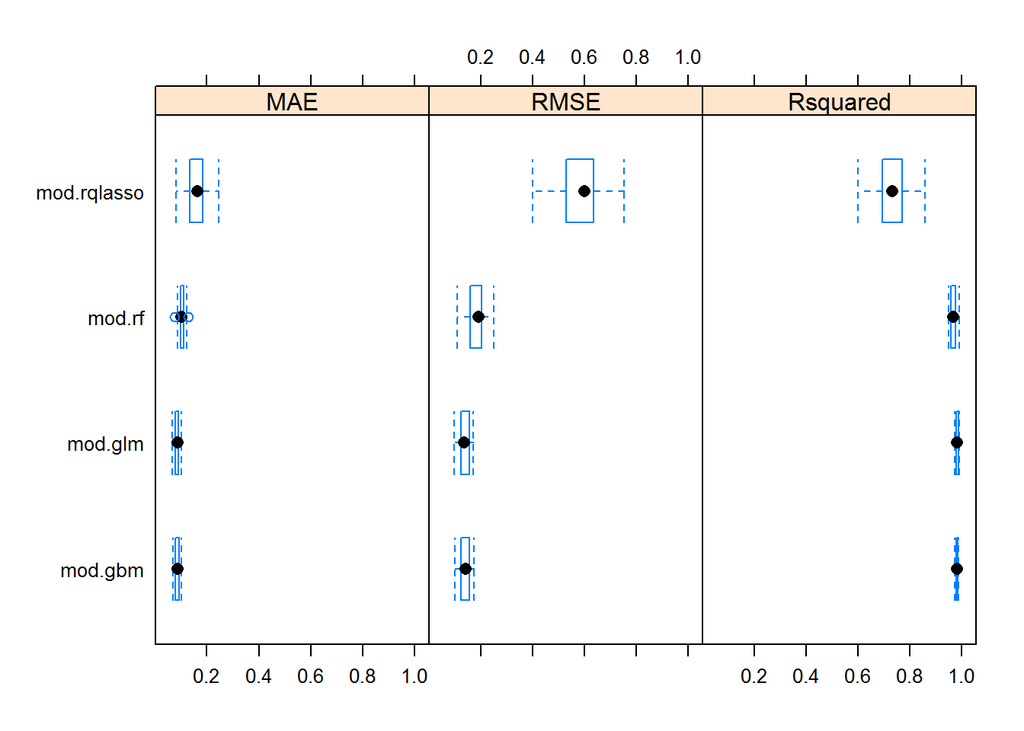

```r
bwplot(results)
```

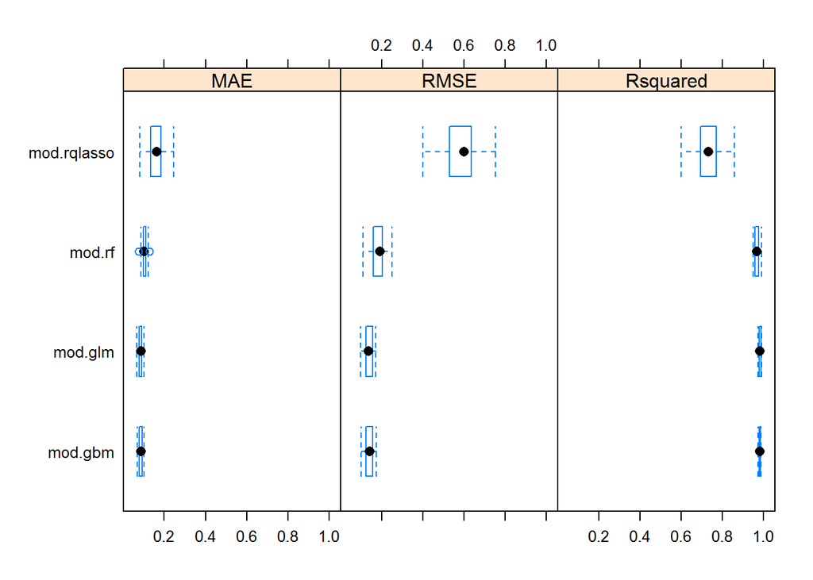

```r
bwplot(results)
```

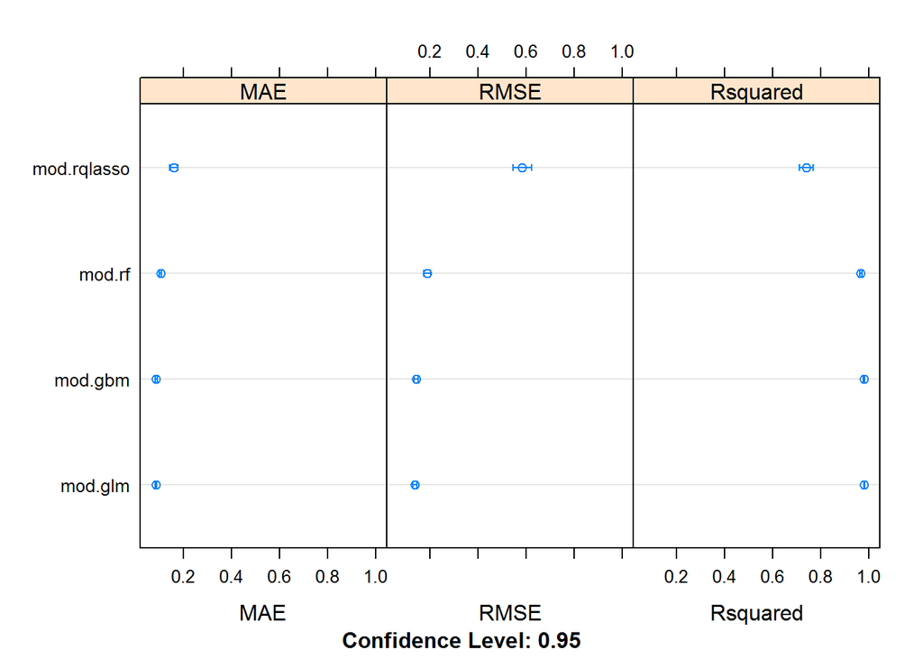

```r
dotplot(results)
```

```r
CPU_time <- proc.time() - ptm
print(CPU_time)
```

```
##    user  system elapsed
## 1151.33   13.25 1224.98
```

## Recherche des outliers

Nous recherchons le modèle linéaire généralisé avec toutes les données, et en utilisant la fonction glm de R base.

```r
names(don)
```

```
##  [1] "Warning_flags"       "A1"                  "A2"
##  [4] "A3"                  "A4"                  "A5"
##  [7] "A6"                  "A7"                  "M1"
## [10] "M2"                  "M3"                  "M4"
## [13] "M5"                  "M6"                  "M7"
## [16] "M8"                  "N"                   "Reduced_chi_squared"
## [19] "Vitesse"             "MGV"                 "clusters_kmeans"
```

```r
model_glm_glm <- glm(MGV~., data=don, family="gaussian")
```

### Avec les rÃ©sidus

Une règle approximative consiste Ã dire que les données aberrantes sont les individus avec un résidus standardisés supérieurs Ã 3.3 (correspondant Ã un niveau de $\alpha$ de .001).

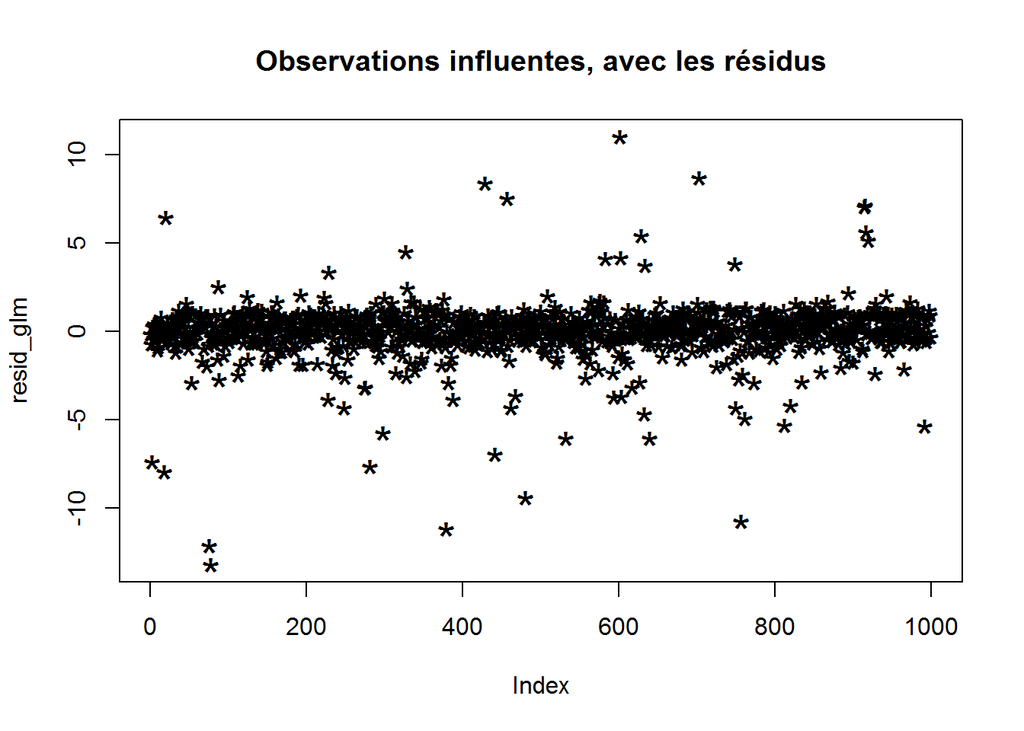

```r
resid_glm <- tail(resid(model_glm_glm),n=1000)

plot(resid_glm, pch="*", cex=2,
     main="Observations influentes, avec les rÃ©sidus")
```

```r
influential <- as.numeric(names(resid_glm)) # Lignes influentes
head(don[influential, ])
```

|  | Warning_flags | A1 | A2 | A3 | A4 | A5 | A6 | A7 | M1 | M2 | M3 | M4 | M5 | M6 | M7 | M8 | N | Reduced_chi_squared | Vitesse | MGV | clusters_kmeans |
| --- | --- | --- | --- | --- | --- | --- | --- | --- | --- | --- | --- | --- | --- | --- | --- | --- | --- | --- | --- | --- | --- |
| 99572 | 00000000 | 3.43478 | 0.00000 | 0.00000 | 0.00000 | 0 | 0 | 0 | 3.370377 | 3.513435 | 0.0000000 | 0.000000 | 0.0000000 | 0 | 0 | 0 | 2 | 1476.420 | 80.13924 | 6.883823 | 1 |
| 99573 | 00000000 | 3.84699 | 5.98907 | 1.35519 | 1.35519 | 0 | 0 | 0 | 4.536269 | 3.601264 | 0.2855127 | 2.373293 | 0.5004241 | 0 | 0 | 0 | 5 | 270.950 | 80.57700 | 11.296738 | 3 |
| 99574 | 00000080 | 3.72414 | 5.33333 | 1.60920 | 0.00000 | 0 | 0 | 0 | 0.000000 | 0.000000 | 0.0000000 | 0.000000 | 0.0000000 | 0 | 0 | 0 | 4 | 325.955 | 84.74472 | 12.397868 | 3 |
| 99575 | 00000000 | 3.78947 | 5.89474 | 1.35673 | 1.30994 | 0 | 0 | 0 | 5.209633 | 8.020092 | 2.1790826 | 3.518858 | 2.9925586 | 0 | 0 | 0 | 5 | 293.416 | 86.23152 | 21.920183 | 3 |
| 99576 | 00000000 | 3.92453 | 5.66038 | 1.35849 | 1.43396 | 0 | 0 | 0 | 5.896616 | 8.010591 | 1.8369929 | 3.074964 | 2.4353823 | 0 | 0 | 0 | 5 | 189.894 | 69.55488 | 21.254536 | 3 |
| 99577 | 00000000 | 3.86441 | 5.86441 | 1.32203 | 1.32203 | 0 | 0 | 0 | 4.825015 | 12.184608 | 5.1997146 | 7.832681 | 7.1656065 | 0 | 0 | 0 | 5 | 743.904 | 62.48124 | 37.207543 | 2 |

```r
don$outlier <- "FALSE"
don[influential,"outlier"] <- "TRUE"

ggplot(don, aes(y=Warning_flags, x=Reduced_chi_squared, group=outlier)) +
  geom_point(aes(shape=outlier, color=outlier))
```

[output not shown]

### Avec la distance de Cook

La distance de Cook est essentiellement une mesure de distance standardisée qui permet de décrire le changement dans l’estimateur de $\beta$ lorsque l’on retire l’observation $i$. Une grande valeur de la distance de Cook suggère que l’observation i possède une grande influence.

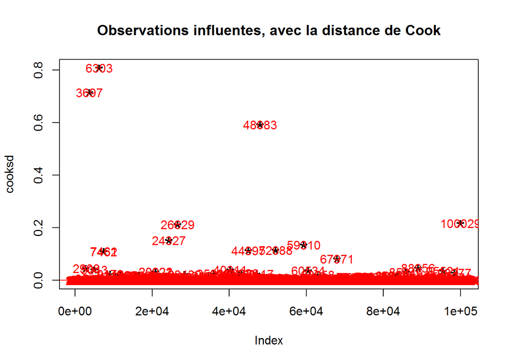

```r
cooksd <- cooks.distance(model_glm_glm)

plot(cooksd, pch="*", cex=2,
     main="Observations influentes, avec la distance de Cook")
abline(h = 4*mean(cooksd, na.rm=T), col="red")
text(x=1:length(cooksd)+1, y=cooksd,
     labels=ifelse(cooksd>4*mean(cooksd, na.rm=T),names(cooksd),""),
     col="red")
```

```r
influential <- names(cooksd[(cooksd > 4*mean(cooksd, na.rm=T))]) # Lignes influentes
influential <- influential[!is.na(influential)]
head(don[influential, ])
```

|  | Warning_flags | A1 | A2 | A3 | A4 | A5 | A6 | A7 | M1 | M2 | M3 | M4 | M5 | M6 | M7 | M8 | N | Reduced_chi_squared | Vitesse | MGV | clusters_kmeans | outlier |
| --- | --- | --- | --- | --- | --- | --- | --- | --- | --- | --- | --- | --- | --- | --- | --- | --- | --- | --- | --- | --- | --- | --- |
| 149 | 00000080 | 1.58454 | 0.00000 | 0.00000 | 0.00000 | 0.00000 | 0 | 0 | 0.000000 | 0.000000 | 0.00000 | 0.00000 | 0.00000 | 0 | 0 | 0 | 2 | 22.7692 | 71.23464 | 7.299760 | 1 | FALSE |
| 228 | 00800001 | 3.81818 | 5.90909 | 1.31818 | 1.36364 | 0.00000 | 0 | 0 | 3.698695 | 3.695301 | 11.05566 | 23.14027 | 9.84472 | 0 | 0 | 0 | 5 | 818.1960 | 83.78172 | 51.434659 | 2 | FALSE |
| 430 | 00000081 | 1.54455 | 0.00000 | 0.00000 | 0.00000 | 0.00000 | 0 | 0 | 0.000000 | 0.000000 | 0.00000 | 0.00000 | 0.00000 | 0 | 0 | 0 | 2 | 314.3470 | 72.99792 | 5.605030 | 1 | FALSE |
| 433 | 00000081 | 1.62376 | 0.00000 | 0.00000 | 0.00000 | 0.00000 | 0 | 0 | 0.000000 | 0.000000 | 0.00000 | 0.00000 | 0.00000 | 0 | 0 | 0 | 2 | 314.3470 | 72.99792 | 5.640992 | 1 | FALSE |
| 504 | 00000080 | 4.80000 | 0.00000 | 0.00000 | 0.00000 | 0.00000 | 0 | 0 | 0.000000 | 0.000000 | 0.00000 | 0.00000 | 0.00000 | 0 | 0 | 0 | 2 | 17.2207 | 89.36712 | 3.451024 | 1 | FALSE |
| 506 | 00000080 | 4.00000 | 4.40000 | 1.22857 | 1.22857 | 7.77143 | 0 | 0 | 0.000000 | 0.000000 | 0.00000 | 0.00000 | 0.00000 | 0 | 0 | 0 | 6 | 429.8350 | 52.66296 | 31.173128 | 2 | FALSE |

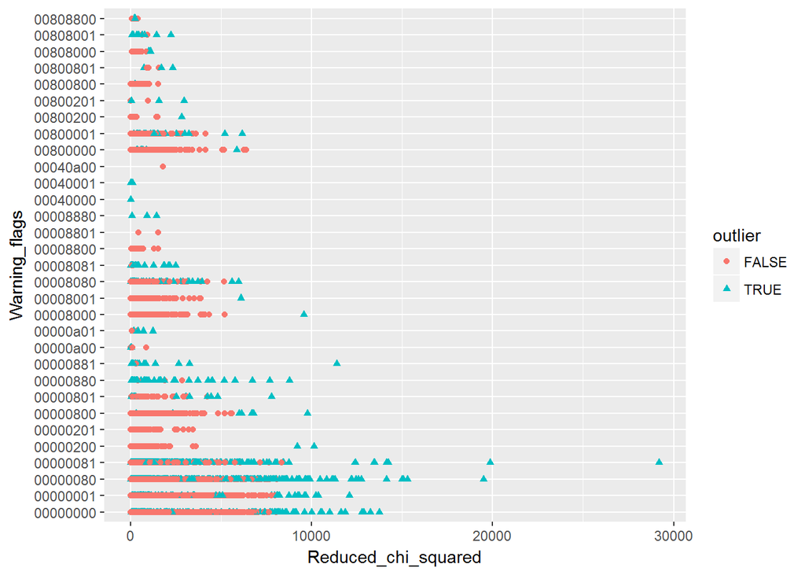

```r
don$outlier <- "FALSE"
don[influential,"outlier"] <- "TRUE"

ggplot(don, aes(y=Warning_flags, x=Reduced_chi_squared, group=outlier)) +
  geom_point(aes(shape=outlier, color=outlier))
```

### Avec les hat values

La statistique de leverage (leverage points = points influents), $h$, aussi appelée hat value (issue de la hat matrice, aussi appelée matrice de projection), identfie les individus qui influencent plus la line de régression que les autres.

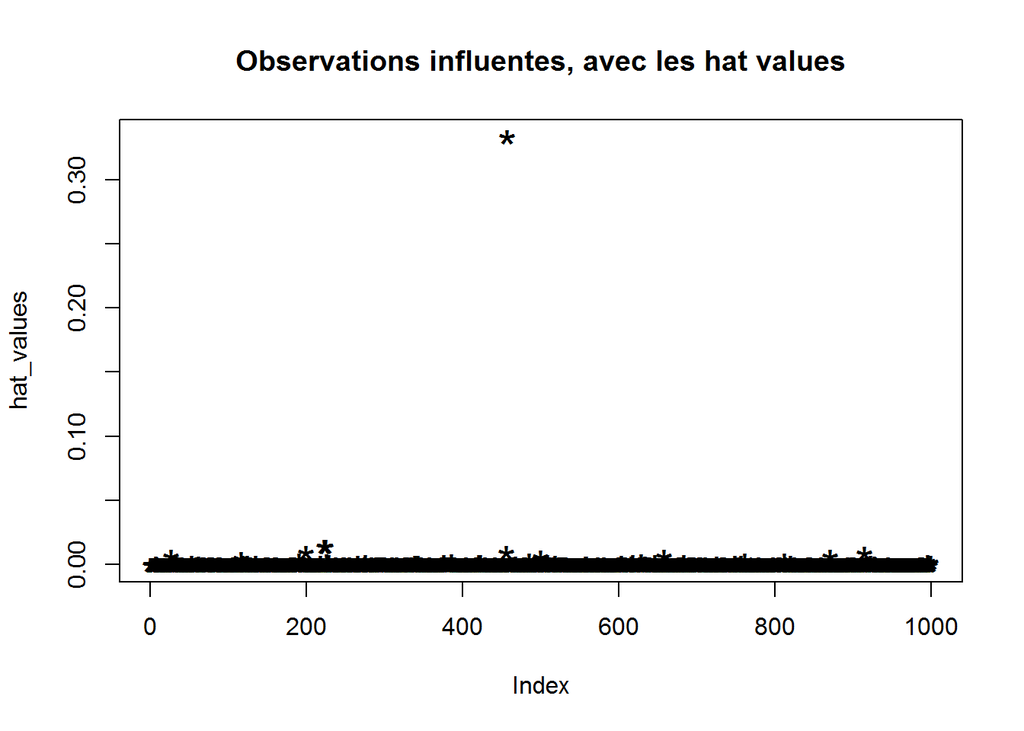

```r
hat_values <- tail(hatvalues(model_glm_glm),n=1000)

plot(hat_values, pch="*", cex=2,
     main="Observations influentes, avec les hat values")
```

```r
influential <- as.numeric(names(hat_values)) # Lignes influentes
head(don[influential, ])
```

|  | Warning_flags | A1 | A2 | A3 | A4 | A5 | A6 | A7 | M1 | M2 | M3 | M4 | M5 | M6 | M7 | M8 | N | Reduced_chi_squared | Vitesse | MGV | clusters_kmeans | outlier |
| --- | --- | --- | --- | --- | --- | --- | --- | --- | --- | --- | --- | --- | --- | --- | --- | --- | --- | --- | --- | --- | --- | --- |
| 99572 | 00000000 | 3.43478 | 0.00000 | 0.00000 | 0.00000 | 0 | 0 | 0 | 3.370377 | 3.513435 | 0.0000000 | 0.000000 | 0.0000000 | 0 | 0 | 0 | 2 | 1476.420 | 80.13924 | 6.883823 | 1 | FALSE |
| 99573 | 00000000 | 3.84699 | 5.98907 | 1.35519 | 1.35519 | 0 | 0 | 0 | 4.536269 | 3.601264 | 0.2855127 | 2.373293 | 0.5004241 | 0 | 0 | 0 | 5 | 270.950 | 80.57700 | 11.296738 | 3 | FALSE |
| 99574 | 00000080 | 3.72414 | 5.33333 | 1.60920 | 0.00000 | 0 | 0 | 0 | 0.000000 | 0.000000 | 0.0000000 | 0.000000 | 0.0000000 | 0 | 0 | 0 | 4 | 325.955 | 84.74472 | 12.397868 | 3 | FALSE |
| 99575 | 00000000 | 3.78947 | 5.89474 | 1.35673 | 1.30994 | 0 | 0 | 0 | 5.209633 | 8.020092 | 2.1790826 | 3.518858 | 2.9925586 | 0 | 0 | 0 | 5 | 293.416 | 86.23152 | 21.920183 | 3 | FALSE |
| 99576 | 00000000 | 3.92453 | 5.66038 | 1.35849 | 1.43396 | 0 | 0 | 0 | 5.896616 | 8.010591 | 1.8369929 | 3.074964 | 2.4353823 | 0 | 0 | 0 | 5 | 189.894 | 69.55488 | 21.254536 | 3 | FALSE |
| 99577 | 00000000 | 3.86441 | 5.86441 | 1.32203 | 1.32203 | 0 | 0 | 0 | 4.825015 | 12.184608 | 5.1997146 | 7.832681 | 7.1656065 | 0 | 0 | 0 | 5 | 743.904 | 62.48124 | 37.207543 | 2 | FALSE |

```r
don$outlier <- "FALSE"
don[influential,"outlier"] <- "TRUE"

ggplot(don, aes(y=Warning_flags, x=Reduced_chi_squared, group=outlier)) +
  geom_point(aes(shape=outlier, color=outlier))
```

[output not shown]

### Avec les rÃ©sidus de r-student

Un résidu studentisé est le résidu observé divisé par l’écart-type.

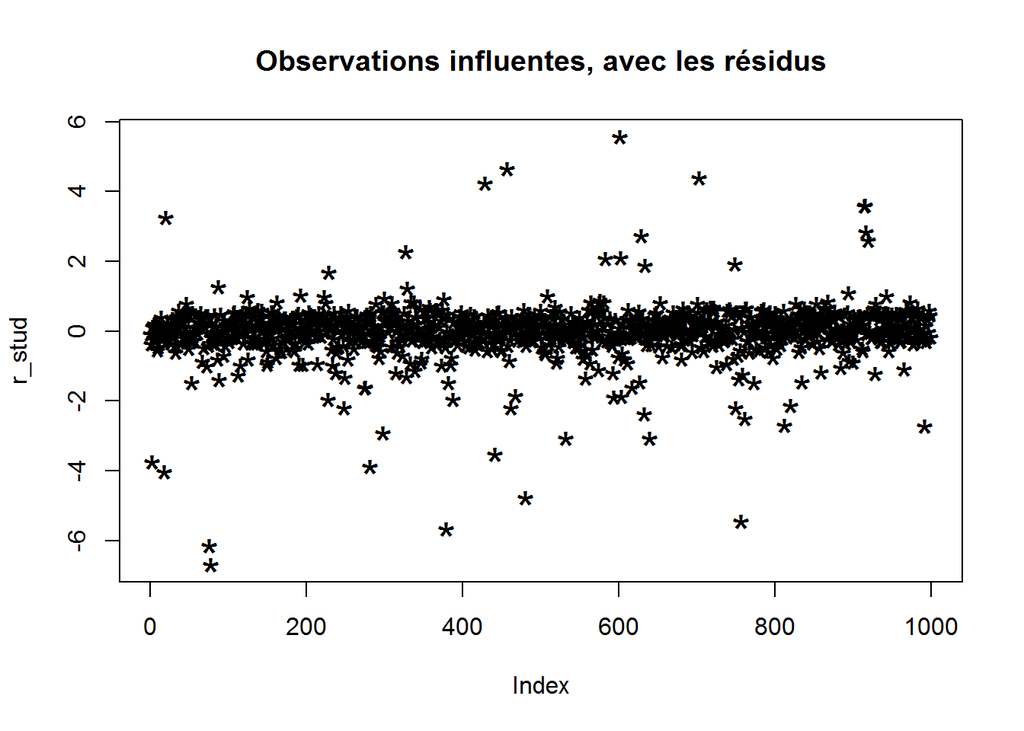

```r
r_stud <- tail(rstudent(model_glm_glm),n=1000)

plot(r_stud, pch="*", cex=2,
     main="Observations influentes, avec les rÃ©sidus")
```

```r
influential <- as.numeric(names(r_stud)) # Lignes influentes
head(don[influential, ])
```

|  | Warning_flags | A1 | A2 | A3 | A4 | A5 | A6 | A7 | M1 | M2 | M3 | M4 | M5 | M6 | M7 | M8 | N | Reduced_chi_squared | Vitesse | MGV | clusters_kmeans | outlier |
| --- | --- | --- | --- | --- | --- | --- | --- | --- | --- | --- | --- | --- | --- | --- | --- | --- | --- | --- | --- | --- | --- | --- |
| 99572 | 00000000 | 3.43478 | 0.00000 | 0.00000 | 0.00000 | 0 | 0 | 0 | 3.370377 | 3.513435 | 0.0000000 | 0.000000 | 0.0000000 | 0 | 0 | 0 | 2 | 1476.420 | 80.13924 | 6.883823 | 1 | TRUE |
| 99573 | 00000000 | 3.84699 | 5.98907 | 1.35519 | 1.35519 | 0 | 0 | 0 | 4.536269 | 3.601264 | 0.2855127 | 2.373293 | 0.5004241 | 0 | 0 | 0 | 5 | 270.950 | 80.57700 | 11.296738 | 3 | TRUE |
| 99574 | 00000080 | 3.72414 | 5.33333 | 1.60920 | 0.00000 | 0 | 0 | 0 | 0.000000 | 0.000000 | 0.0000000 | 0.000000 | 0.0000000 | 0 | 0 | 0 | 4 | 325.955 | 84.74472 | 12.397868 | 3 | TRUE |
| 99575 | 00000000 | 3.78947 | 5.89474 | 1.35673 | 1.30994 | 0 | 0 | 0 | 5.209633 | 8.020092 | 2.1790826 | 3.518858 | 2.9925586 | 0 | 0 | 0 | 5 | 293.416 | 86.23152 | 21.920183 | 3 | TRUE |
| 99576 | 00000000 | 3.92453 | 5.66038 | 1.35849 | 1.43396 | 0 | 0 | 0 | 5.896616 | 8.010591 | 1.8369929 | 3.074964 | 2.4353823 | 0 | 0 | 0 | 5 | 189.894 | 69.55488 | 21.254536 | 3 | TRUE |
| 99577 | 00000000 | 3.86441 | 5.86441 | 1.32203 | 1.32203 | 0 | 0 | 0 | 4.825015 | 12.184608 | 5.1997146 | 7.832681 | 7.1656065 | 0 | 0 | 0 | 5 | 743.904 | 62.48124 | 37.207543 | 2 | TRUE |

```r
don$outlier <- "FALSE"
don[influential,"outlier"] <- "TRUE"

ggplot(don, aes(y=Warning_flags, x=Reduced_chi_squared, group=outlier)) +
  geom_point(aes(shape=outlier, color=outlier))
```

[output not shown]